# TFM

Maria del Mar Escalas Martorell

2023-06-19

Load libraries.

```r
# General libraries:
library(tidyverse)
library(stringr) # regex
library(sf) # geometry polygons and plots (maps)

# Dates
library(zoo)

# Web scraping libraries:
library(xml2)
library(httr)
library(scrapex)
library(rvest) # read_html

# Plots and maps
library(leaflet)

# Times New Roman font import:
library(extrafont)
```

## 3. DATA EXTRACTION AND PREPROCESSING

### 3.1. Dwellings’ characteristics data

#### 3.1.1. Idealista (2023)

Extraction of data from a private API:

- Reading personal private credentials (hidden): user’s personal credentials are provided by API’s host. It is shown below how they should be loaded in R from a hidden location in the computer. In this case, credentials are stored in a separated folder (not included in the data available in the repository). Instead of using this directory, the person who wishes to reproduce this code should introduce its own credentials.

```r
# consumer_apikey <- readLines("../Secret/consumer_apikey.txt")
# consumer_secret <- readLines("../Secret/consumer_secret.txt")
# api_key_secret <- paste0(consumer_apikey, ":", consumer_secret)
```

- Using basic authentication: credentials should be encoded and the token needs to be build.

```r
# secret <- base64_enc(api_key_secret)
#
# req <- httr::POST("https://api.idealista.com/oauth/token",
#        httr::add_headers(
#          "Authorization" = paste("Basic", secret, sep = " "),
#          "Content-Type" = "application/x-www-form-urlencoded;charset=utf-8"
#             ),
#        body = "grant_type=client_credentials&scope=read"
#             )
#
# token <- paste("Bearer", httr::content(req)$access_token)
```

- Start building the request: establishing the desired parameters to search.

```r
# site = "https://api.idealista.com/3.5/es/search?" # official site provided by the host
# loc = "center=" # location reference
# x = 40.40691 # latitude
# y = -3.70958 # longitude
# country = "&country=es" # Spain
# maxItems = "&maxItems=50" # maximum items allowed for the request to return = 50
# pages = "&numPage=1"
# dist = "&distance="
# distance = 1000 # distance from the location reference (radius)
# property = "&propertyType="
# type = "homes"
# operation = "&operation="
# op = "sale" # only sales (not rentals)
# chalet = "&chalet=0" (no chalets)
```

- Building the url.

```r
# url1 <- paste(site, loc, x, ',', y, country, maxItems, pages, dist, distance,
#              property, type, operation, op, sep = "")
```

- Requesting the information through Idealista’s API.

```r
# res1 <- httr::POST(url1, httr::add_headers("Authorization" = token))
```

- Extracting the JSON content (a dataframe is obtained).

```r
# cont_raw2 <- httr::content(res1)
```

#### 3.1.2. Idealista (2018)

Database from Idealista (private online Real Estate portal).

Load needed package.

```r
# devtools::install_github("paezha/idealista18")
library(idealista18)
```

Data from Madrid 2018.

```r
data("Madrid_Sale")
class(Madrid_Sale)
```

```
## [1] "sf"         "data.frame"
```

```r
idealista18 <- Madrid_Sale %>%
  select(ASSETID, PERIOD, PRICE, CONSTRUCTEDAREA, UNITPRICE, ROOMNUMBER,
         BATHNUMBER, HASTERRACE, HASLIFT, HASAIRCONDITIONING,
         ISPARKINGSPACEINCLUDEDINPRICE, HASNORTHORIENTATION,
         HASSOUTHORIENTATION, HASEASTORIENTATION, HASWESTORIENTATION,
         HASBOXROOM, HASWARDROBE, HASSWIMMINGPOOL, HASDOORMAN, HASGARDEN,
         FLATLOCATIONID, CADCONSTRUCTIONYEAR, CADMAXBUILDINGFLOOR,
         CADDWELLINGCOUNT, DISTANCE_TO_CITY_CENTER, DISTANCE_TO_METRO,
         LONGITUDE, LATITUDE) %>%
  rename(id = ASSETID, period = PERIOD, price = PRICE,
         built_area = CONSTRUCTEDAREA, price_sq_m = UNITPRICE,
         n_room = ROOMNUMBER, n_bath = BATHNUMBER, terrace = HASTERRACE,
         lift = HASLIFT, air_cond = HASAIRCONDITIONING,
         parking = ISPARKINGSPACEINCLUDEDINPRICE,
         north_orientation = HASNORTHORIENTATION,
         south_orientation = HASSOUTHORIENTATION,
         east_orientation = HASEASTORIENTATION,
         west_orientation = HASWESTORIENTATION, boxroom = HASBOXROOM,
         wardrobe = HASWARDROBE, pool = HASSWIMMINGPOOL,
         doorman = HASDOORMAN, garden = HASGARDEN,
         external = FLATLOCATIONID, year_built = CADCONSTRUCTIONYEAR,
         floors = CADMAXBUILDINGFLOOR, n_dwelling = CADDWELLINGCOUNT,
         km_to_center = DISTANCE_TO_CITY_CENTER,
         metro_proximity = DISTANCE_TO_METRO, long = LONGITUDE, lat = LATITUDE)
```

Issues with raw data:

- There is a difference between unique row number and the total number of rows.

```r
nrow(idealista18) - length(unique(idealista18$id))
```

```
## [1] 19011
```

- There are many dwellings without orientation.

```r
idealista18 %>% filter(north_orientation == 0 & south_orientation == 0 & east_orientation == 0 & west_orientation == 0)
```

```
## Simple feature collection with 49202 features and 28 fields
## Geometry type: POINT
## Dimension:     XY
## Bounding box:  xmin: -3.826759 ymin: 36.75639 xmax: -2.753303 ymax: 40.52064
## Geodetic CRS:  WGS 84
## First 10 features:
##                       id period  price built_area price_sq_m n_room n_bath
## 1  A15019136831406238029 201803 126000         47   2680.851      1      1
## 2   A6677225905472065344 201803 235000         54   4351.852      1      1
## 3   A4775182175615276542 201803 284000         48   5916.667      1      1
## 4   A2492087730711701973 201803 228000         50   4560.000      0      1
## 5  A18372428154681111419 201803 498000        127   3921.260      3      2
## 6   A4705946410795464036 201803 225000         35   6428.571      0      1
## 7   A8243762537477781718 201803 365000        100   3650.000      2      1
## 8   A1682702257758295446 201803 213000         40   5325.000      1      1
```

[output cut: 46 more lines]

- Dropping geometry to make operations.

```r
idealista18 <- st_drop_geometry(idealista18)
```

- Recoding of external. If “yes” = 1, if “no” = 0.

```r
idealista18 <- idealista18 %>%
  mutate(external = case_when(external == 2 ~ 0,
                              external == 1 ~ 1,
                              is.na(external) ~ NA_real_))
```

Operations:

- Max for logical variables (in numeric format)
- Average for numerical (continuous) variables

```r
idealista <- idealista18 %>%
  group_by(id) %>%
  mutate(across(c(period, price, built_area, n_room, n_bath,
                  year_built, floors, n_dwelling,
                  km_to_center, metro_proximity, long, lat), mean),
         across(c(terrace, lift, air_cond, parking,
                  north_orientation, south_orientation, east_orientation,
                  west_orientation, boxroom, wardrobe, pool, doorman,
                  garden, external), ~max(.)),
         across(c(price, built_area, price_sq_m, n_room, n_bath), round))

sapply(idealista, function(x) sum(is.na(x))*100/nrow(idealista)) # to check % of NAs per row
```

```
##                id            period             price        built_area
##           0.00000           0.00000           0.00000           0.00000
##        price_sq_m            n_room            n_bath           terrace
##           0.00000           0.00000           0.00000           0.00000
##              lift          air_cond           parking north_orientation
##           0.00000           0.00000           0.00000           0.00000
## south_orientation  east_orientation  west_orientation           boxroom
##           0.00000           0.00000           0.00000           0.00000
##          wardrobe              pool           doorman            garden
##           0.00000           0.00000           0.00000           0.00000
##          external        year_built            floors        n_dwelling
##           6.97358           0.00000           0.00000           0.00000
##      km_to_center   metro_proximity              long               lat
##           0.00000           0.00000           0.00000           0.00000
```

```r
idealista <- idealista %>% distinct(id, .keep_all = TRUE) %>% drop_na() # to drop rows with no information available about 'external'
```

- Classifying orientation:

```r
idealista <- idealista %>%
  mutate(orientation = as_factor(case_when(
  north_orientation == "0" & south_orientation == "0" & east_orientation == "0" & west_orientation == "0" ~ "None",
  north_orientation == "1" & south_orientation == "0" & east_orientation == "0" & west_orientation == "0" ~ "Low", # north
  north_orientation == "0" & south_orientation == "0" & east_orientation == "0" & west_orientation == "1" ~ "Medium", # west
  north_orientation == "0" & south_orientation == "0" & east_orientation == "1" & west_orientation == "0" ~ "Medium", # east
  north_orientation == "0" & south_orientation == "0" & east_orientation == "1" & west_orientation == "1" ~ "Medium", # east-west
  north_orientation == "1" & south_orientation == "0" & east_orientation == "0" & west_orientation == "1" ~ "Medium", # north-west
  north_orientation == "1" & south_orientation == "0" & east_orientation == "1" & west_orientation == "0" ~ "Medium", # north-east
  north_orientation == "1" & south_orientation == "0" & east_orientation == "1" & west_orientation == "1" ~ "Medium", # north-east-west
  north_orientation == "0" & south_orientation == "1" & east_orientation == "0" & west_orientation == "0" ~ "Good", # south
  north_orientation == "0" & south_orientation == "1" & east_orientation == "0" & west_orientation == "1" ~ "Good", # south-west
  north_orientation == "0" & south_orientation == "1" & east_orientation == "1" & west_orientation == "0" ~ "Good", # south-east
  north_orientation == "1" & south_orientation == "1" & east_orientation == "0" & west_orientation == "0" ~ "Good", # south-north
  north_orientation == "0" & south_orientation == "1" & east_orientation == "1" & west_orientation == "1" ~ "Good", # south-east-west
  north_orientation == "1" & south_orientation == "1" & east_orientation == "1" & west_orientation == "0" ~ "Good", # south-north-east
  north_orientation == "1" & south_orientation == "1" & east_orientation == "0" & west_orientation == "1" ~ "Good", # south-north-west
  north_orientation == "1" & south_orientation == "1" & east_orientation == "1" & west_orientation == "1" ~ "Full")),
         period = case_when(period == 201803 ~ "20181",
                            period == 201806 ~ "20182",
                            period == 201809 ~ "20183",
                            period == 201812 ~ "20184"),
         period = as.yearqtr(format(period), "%Y%q")) %>%
  select(-c(north_orientation, south_orientation, east_orientation, west_orientation))
```

- Reconverting the dataframe into a geometry object.

```r
idealista <- st_as_sf(idealista, coords = c("long", "lat"), crs = 4326)
```

- Joining each dwelling with its corresponding neighbourhood.

```r
madrid_idealista <- st_join(idealista, Madrid_Polygons, join = st_within)

madrid_idealista <- madrid_idealista %>%
  select(-c(LOCATIONID, ZONELEVELID)) %>%
  rename(neighbourhood = LOCATIONNAME)
```

- Incorporating coordinates again.

```r
madrid_idealista <- madrid_idealista %>%
  mutate(long = st_coordinates(geometry)[, 1],
         lat = st_coordinates(geometry)[, 2])
```

Identification of observations that contain errors:

- A10991866817670907438: price = 450000, n_rooms = 93 (wrong number of rooms)
- A8866129769871540210: price = 109000, n_rooms = 33 (wrong number of rooms)

```r
madrid_idealista %>% filter(n_room > 25)
```

```
## Simple feature collection with 2 features and 26 fields
## Geometry type: POINT
## Dimension:     XY
## Bounding box:  xmin: -3.704526 ymin: 40.38417 xmax: -3.623555 ymax: 40.40096
## Geodetic CRS:  WGS 84
## # A tibble: 2 × 27
##   id    period  price built_area price_sq_m n_room n_bath terrace  lift air_cond
## * <fct> <year>  <dbl>      <dbl>      <dbl>  <dbl>  <dbl>   <int> <int>    <int>
## 1 A109… 2018 … 450000        119       3782     93      2       1     1        1
## 2 A886… 2018 … 109000         90       1211     33      2       0     1        1
## # ℹ 17 more variables: parking <int>, boxroom <int>, wardrobe <int>,
## #   pool <int>, doorman <int>, garden <int>, external <dbl>, year_built <dbl>,
## #   floors <dbl>, n_dwelling <dbl>, km_to_center <dbl>, metro_proximity <dbl>,
## #   orientation <fct>, geometry <POINT [°]>, neighbourhood <fct>, long <dbl>,
## #   lat <dbl>
```

- A7501251371917084834: long = - 2.753303, lat = 36.75639 (house located in Almería)

```r
madrid_idealista %>% filter(long > -3.50 & lat < 40.00)
```

```
## Simple feature collection with 1 feature and 26 fields
## Geometry type: POINT
## Dimension:     XY
## Bounding box:  xmin: -2.753303 ymin: 36.75639 xmax: -2.753303 ymax: 36.75639
## Geodetic CRS:  WGS 84
## # A tibble: 1 × 27
##   id    period  price built_area price_sq_m n_room n_bath terrace  lift air_cond
## * <fct> <year>  <dbl>      <dbl>      <dbl>  <dbl>  <dbl>   <int> <int>    <int>
## 1 A750… 2018 … 191000        145       1317      4      2       0     1        1
## # ℹ 17 more variables: parking <int>, boxroom <int>, wardrobe <int>,
## #   pool <int>, doorman <int>, garden <int>, external <dbl>, year_built <dbl>,
## #   floors <dbl>, n_dwelling <dbl>, km_to_center <dbl>, metro_proximity <dbl>,
## #   orientation <fct>, geometry <POINT [°]>, neighbourhood <fct>, long <dbl>,
## #   lat <dbl>
```

- Removing wrong observations.

```r
madrid_idealista <- madrid_idealista %>%
  filter(!(long > -3.50 & lat < 40.00)) %>%
  filter(!(price %in% c(450000, 109000) & n_room %in% c(93, 33)))
```

Check for *NA* percentage in each column:

```r
sapply(madrid_idealista, function(x) sum(is.na(x))*100/nrow(madrid_idealista))
```

```
##              id          period           price      built_area      price_sq_m
##      0.00000000      0.00000000      0.00000000      0.00000000      0.00000000
##          n_room          n_bath         terrace            lift        air_cond
##      0.00000000      0.00000000      0.00000000      0.00000000      0.00000000
##         parking         boxroom        wardrobe            pool         doorman
##      0.00000000      0.00000000      0.00000000      0.00000000      0.00000000
##          garden        external      year_built          floors      n_dwelling
##      0.00000000      0.00000000      0.00000000      0.00000000      0.00000000
##    km_to_center metro_proximity     orientation        geometry   neighbourhood
##      0.00000000      0.00000000      0.00000000      0.00000000      0.09352549
##            long             lat
##      0.00000000      0.00000000
```

```r
madrid_idealista %>% filter(is.na(neighbourhood)) %>% arrange(id)
```

```
## Simple feature collection with 66 features and 26 fields
## Geometry type: POINT
## Dimension:     XY
## Bounding box:  xmin: -3.800877 ymin: 40.33973 xmax: -3.580351 ymax: 40.50092
## Geodetic CRS:  WGS 84
## # A tibble: 66 × 27
##    id            period  price built_area price_sq_m n_room n_bath terrace  lift
##    <fct>         <year>  <dbl>      <dbl>      <dbl>  <dbl>  <dbl>   <int> <int>
##  1 A10040860376… 2018 … 970000        236       4110      5      5       1     1
##  2 A10477074059… 2018 … 916500        240       3850      5      5       1     1
##  3 A10555682128… 2018 … 791000        192       4120      4      3       1     1
##  4 A11024076574… 2018 … 622000        165       3770      4      3       1     1
##  5 A11875273696… 2018 … 165500         55       3000      2      1       0     0
##  6 A12040050961… 2018 … 263333         93       2871      2      2       0     1
##  7 A12212158607… 2018 … 157500         85       1871      3      2       0     1
##  8 A12275460312… 2018 … 875000        230       3804      5      4       1     1
##  9 A12427375718… 2018 … 477000        100       4770      2      2       1     1
## 10 A12449866803… 2018 … 878000        202       4347      5      3       0     1
## # ℹ 56 more rows
## # ℹ 18 more variables: air_cond <int>, parking <int>, boxroom <int>,
## #   wardrobe <int>, pool <int>, doorman <int>, garden <int>, external <dbl>,
## #   year_built <dbl>, floors <dbl>, n_dwelling <dbl>, km_to_center <dbl>,
## #   metro_proximity <dbl>, orientation <fct>, geometry <POINT [°]>,
## #   neighbourhood <fct>, long <dbl>, lat <dbl>
```

After a deeper investigation it has been found that those remaining dwellings without neighbourhood information are located in the main streets or avenues which are found in the boundaries of two neighbourhoods. The decision has been to consult manually the location and assign a neighbourhood according to the part of the street where these houses are found. Despite this small detail, neighbourhood itself will not be as important for this study, the interest is mainly in the district, which is the same for the two neighbourhoods. Only dwellings from the three first quarters of the year will be handled because, as explained later, the analysis is only going to be considering this period.

```r
missing_n <- data.frame(madrid_idealista %>%
  filter(id %in% c("A16435294318315958522", "A713741178483582771", "A17974577062442055154", "A7640522779001274113",
                   "A16293887458042174614", "A2558868114930352875", "A10040860376639148021", "A11024076574113822412",
                   "A8975421952301567018", "A15391127164769132499", "A7276195934098417167", "A14373658715532580887",
                   "A12512273801481420708", "A4124869518560963783", "A1047707405959696934", "A14527656687040890533",
                   "A392049767746391904", "A9152666484316798621", "A10555682128559782831", "A1770016731578591700",
                   "A2850681705060765887", "A15122532253238651164", "A11875273696714479769", "A2916148036363906874",
                   "A8323672166361605012", "A14425820252961357301", "A16832610759102053201", "A16175240154493734292",
                   "A12449866803255143264", "A6566989044715844699", "A4695742828180854443", "A8834840793393699611",
                   "A2371944396876658222", "A17669068010471096780", "A12275460312855642440", "A13456631820999789083",
                   "A2415811276745293011", "A12855371497725279279", "A12427375718741803668", "A15415301456868430114",
                   "A13947664044826473945")) %>%
  mutate(neighbourhood = c("Legazpi", "Castilla", "Palomeras Bajas", "Piovera", "Pinar del Rey",
                           "Valdebebas - Valdefuentes", "Valdebebas - Valdefuentes", "Valdebebas - Valdefuentes",
                           "Casco Histórico de Vallecas", "Adelfas", "Ciudad Jardín", "Nueva España", "Nueva España",
                           "Ciudad Universitaria", "Valdebebas - Valdefuentes", "Valdefuentes",
                           "Valdebebas - Valdefuentes", "Valdebebas - Valdefuentes", "Valdebebas - Valdefuentes",
                           "Alameda de Osuna", "Legazpi", "Estrella", "Valdeacederas", "Castillejos",
                           "Puerta del Ángel", "Valdebebas - Valdefuentes", "Valdebebas - Valdefuentes",
                           "Valdebebas - Valdefuentes", "Arapiles", "Cuatro Caminos", "Buenavista", "Vinateros",
                           "Valdebebas - Valdefuentes", "Valdebebas - Valdefuentes", "Valdebebas - Valdefuentes",
                           "Delicias", "Peñagrande", "Valdebebas -Valdefuentes", "Valdebebas - Valdefuentes",
                           "Valdebebas - Valdefuentes", "Casco Histórico de Vallecas"))) %>%
  st_drop_geometry()

missing_n
```

```
##                       id  period   price built_area price_sq_m n_room n_bath
## 1  A16435294318315958522 2018 Q1  227000         50       4540      2      1
## 2    A713741178483582771 2018 Q1  811000        141       5752      3      4
## 3  A17974577062442055154 2018 Q1   88000         65       1354      2      1
## 4   A7640522779001274113 2018 Q1  348000        110       3164      3      2
## 5  A16293887458042174614 2018 Q1  141000         70       2014      2      1
## 6   A2558868114930352875 2018 Q1  488000        100       4880      2      2
## 7  A10040860376639148021 2018 Q1  970000        236       4110      5      5
## 8  A11024076574113822412 2018 Q1  622000        165       3770      4      3
## 9   A8975421952301567018 2018 Q1  157000         63       2492      2      2
## 10 A15391127164769132499 2018 Q1  575000        105       5476      2      2
## 11  A7276195934098417167 2018 Q1  791000        150       5273      3      3
## 12 A14373658715532580887 2018 Q1  379500         85       4518      3      1
## 13 A12512273801481420708 2018 Q1  513000        145       3538      4      2
## 14  A4124869518560963783 2018 Q1 1379000        400       3448      5      5
```

[output cut: 153 more lines]

```r
madrid_idealista <- madrid_idealista %>%
  filter(!(id %in% c("A16435294318315958522", "A713741178483582771", "A17974577062442055154", "A7640522779001274113",
                   "A16293887458042174614", "A2558868114930352875", "A10040860376639148021", "A11024076574113822412",
                   "A8975421952301567018", "A15391127164769132499", "A7276195934098417167", "A14373658715532580887",
                   "A12512273801481420708", "A4124869518560963783", "A1047707405959696934", "A14527656687040890533",
                   "A392049767746391904", "A9152666484316798621", "A10555682128559782831", "A1770016731578591700",
                   "A2850681705060765887", "A15122532253238651164", "A11875273696714479769", "A2916148036363906874",
                   "A8323672166361605012", "A14425820252961357301", "A16832610759102053201", "A16175240154493734292",
                   "A12449866803255143264", "A6566989044715844699", "A4695742828180854443", "A8834840793393699611",
                   "A2371944396876658222", "A17669068010471096780", "A12275460312855642440", "A13456631820999789083",
                   "A2415811276745293011", "A12855371497725279279", "A12427375718741803668", "A15415301456868430114",
                   "A13947664044826473945"))) %>%
  st_drop_geometry()

madrid_idealista <- madrid_idealista %>% bind_rows(missing_n) %>% select(-geometry)
```

Cleaned Idealista’s data.

```r
madrid_idealista
```

```
## # A tibble: 70,569 × 26
##    id            period  price built_area price_sq_m n_room n_bath terrace  lift
##    <fct>         <year>  <dbl>      <dbl>      <dbl>  <dbl>  <dbl>   <int> <int>
##  1 A15019136831… 2018 … 1.26e5         47       2681      1      1       0     1
##  2 A66772259054… 2018 … 2.35e5         54       4352      1      1       0     0
##  3 A13341979748… 2018 … 3.73e5         75       4973      2      1       0     0
##  4 A47751821756… 2018 … 2.66e5         44       5917      1      1       0     1
##  5 A24920877307… 2018 … 2.28e5         50       4560      0      1       0     0
##  6 A18372428154… 2018 … 4.98e5        127       3921      3      2       0     1
##  7 A47059464107… 2018 … 2.25e5         35       6429      0      1       0     1
##  8 A82437625374… 2018 … 3.65e5        100       3650      2      1       1     1
##  9 A95874495076… 2018 … 4.25e5         70       6071      1      1       0     1
## 10 A36943005183… 2018 … 3.16e6        360       8853      4      3       1     1
## # ℹ 70,559 more rows
## # ℹ 17 more variables: air_cond <int>, parking <int>, boxroom <int>,
## #   wardrobe <int>, pool <int>, doorman <int>, garden <int>, external <dbl>,
## #   year_built <dbl>, floors <dbl>, n_dwelling <dbl>, km_to_center <dbl>,
## #   metro_proximity <dbl>, orientation <fct>, neighbourhood <chr>, long <dbl>,
## #   lat <dbl>
```

### 3.2. Other external data

#### 3.2.1. Euribor

Scrap of Euribor data:

- Identifying who is scraping with *my user agent*: this step is not compulsory/required, but is highly recommended. Each user should introduce their information regarding profile and device, so that the scraped website is aware of who is doing so and if the user is causing any inconvenience they could be rapidly contacted with no further grievance.

```r
# set_config(user_agent("User Agent; Name Surname Surname (occupation or purpose) / email"))
```

- Reading the website into R.

```r
link_euribor <- "https://datosmacro.expansion.com/hipotecas/euribor?anio=2018"
html_website <- link_euribor %>% read_html()
html_website
```

```
## {html_document}
## <html lang="es" dir="ltr" prefix="og: https://ogp.me/ns#">
## [1] <head>\n<meta http-equiv="Content-Type" content="text/html; charset=UTF-8 ...
## [2] <body itemscope itemtype="https://schema.org/WebPage" class="path-node pa ...
```

- Selecting the desired table.

```r
euribor18 <- html_website %>%
  html_table() %>%
  .[[3]]

euribor18
```

```
## # A tibble: 13 × 4
##    Fecha                          Tipo                          Var.  `Var. Año`
##    <chr>                          <chr>                         <chr> <chr>
##  1 Diciembre 2018                 -0,129%                       0,018 0,061
##  2 Noviembre 2018                 -0,147%                       0,007 0,042
##  3 Octubre 2018                   -0,154%                       0,012 0,026
##  4 Septiembre 2018                -0,166%                       0,003 0,002
##  5 Agosto 2018                    -0,169%                       0,011 -0,013
##  6 Julio 2018                     -0,180%                       0,001 -0,026
##  7 Junio 2018                     -0,181%                       0,007 -0,032
##  8 Mayo 2018                      -0,188%                       0,002 -0,061
##  9 Abril 2018                     -0,190%                       0,001 -0,071
## 10 Marzo 2018                     -0,191%                       0     -0,081
## 11 Febrero 2018                   -0,191%                       -0,0… -0,085
## 12 Enero 2018                     -0,189%                       0,001 -0,094
## 13 < Euribor  2017Euribor  2019 > < Euribor  2017Euribor  2019… < Eu… < Euribor…
```

- Handling needed data.

```r
euribor18 <- euribor18 %>%
  select(Fecha, Tipo) %>%
  rename(month_sp = Fecha, value = Tipo) %>%
  slice(1:(nrow(euribor18) - 1)) # to remove last row

euribor18 <- euribor18 %>%
  mutate(month_sp = str_replace_all(month_sp, " 2018", ""), # to eliminate "2018" from each row in "Fecha" (date) column
         value = str_replace_all(value, ",", ".")) %>% # to replace commas per dots
  mutate(month = case_when( # to manually translate month names
    month_sp == "Enero" ~ "January",
    month_sp == "Febrero" ~ "February",
    month_sp == "Marzo" ~ "March",
    month_sp == "Abril" ~ "April",
    month_sp == "Mayo" ~ "May",
    month_sp == "Junio" ~ "June",
    month_sp == "Julio" ~ "July",
    month_sp == "Agosto" ~ "August",
    month_sp == "Septiembre" ~ "September",
    month_sp == "Octubre" ~ "October",
    month_sp == "Noviembre" ~ "November",
    month_sp == "Diciembre" ~ "December",
    TRUE ~ NA_character_
  )) %>%
  select(month, value, -month_sp)

euribor18
```

```
## # A tibble: 12 × 2
##    month     value
##    <chr>     <chr>
##  1 December  -0.129%
##  2 November  -0.147%
##  3 October   -0.154%
##  4 September -0.166%
##  5 August    -0.169%
##  6 July      -0.180%
##  7 June      -0.181%
##  8 May       -0.188%
##  9 April     -0.190%
## 10 March     -0.191%
## 11 February  -0.191%
## 12 January   -0.189%
```

- Assigning each month its corresponding quarter.

```r
euribor18_q <- euribor18 %>%
  mutate(period = case_when(
    month %in% c("December", "November", "October") ~ "20184",
    month %in% c("September", "August", "July") ~ "20183",
    month %in% c("June", "May", "April") ~ "20182",
    month %in% c("March", "February", "January") ~ "20181"),
         period = as.yearqtr(format(period), "%Y%q"),
         value = str_replace_all(value, "%", ""),
         value = as.numeric(value)
    )
```

- Grouping by quarter and calculating average Euribor per each period.

```r
euribor18_q <- euribor18_q %>%
  select(period, value) %>%
  group_by(period) %>%
  summarise(average_euribor = round(mean(value),4))

euribor18_q
```

```
## # A tibble: 4 × 2
##   period    average_euribor
##   <yearqtr>           <dbl>
## 1 2018 Q1            -0.190
## 2 2018 Q2            -0.186
## 3 2018 Q3            -0.172
## 4 2018 Q4            -0.143
```

- Joining with the main dataset.

```r
madrid_idealista <- madrid_idealista %>%
  full_join(euribor18_q, by = "period")
```

#### 3.2.2. Airbnb

Extraction of information regarding number of houses and places present in Airbnb in each corresponding neighbourhood. Then each dwelling will be assigned a number depending the neighbourhood where it is found.

- Reading raw data from .csv file.

```r
airbnb <- read_csv("Data/airbnb_data.csv", show_col_types = FALSE)

airbnb
```

```
## # A tibble: 27,762 × 13
##    id           url   longitude latitude found               revised
##    <chr>        <chr>     <dbl>    <dbl> <dttm>              <dttm>
##  1 airbnb59923… http…     -4.52     40.3 2017-08-14 21:02:24 2017-09-06 08:16:36
##  2 airbnb59923… http…     -4.52     40.3 2017-08-14 21:02:25 2018-06-03 18:48:53
##  3 airbnb59923… http…     -4.52     40.3 2017-08-14 21:01:52 2018-06-03 18:48:28
##  4 airbnb59923… http…     -4.52     40.3 2017-08-14 21:01:52 2018-06-03 18:48:18
##  5 airbnb59923… http…     -4.52     40.3 2017-08-14 21:01:52 2018-06-03 18:48:25
##  6 airbnb59923… http…     -4.47     40.3 2017-08-14 21:03:48 2018-04-20 20:40:35
##  7 airbnb59923… http…     -4.45     40.2 2017-08-14 21:03:40 2018-06-18 01:37:31
##  8 airbnb59923… http…     -4.43     40.3 2018-05-08 07:25:19 2018-06-03 18:51:53
##  9 airbnb59923… http…     -4.43     40.3 2017-08-14 21:03:44 2018-09-23 06:40:07
## 10 airbnb59923… http…     -4.44     40.3 2017-08-14 21:03:20 2018-09-23 06:15:30
## # ℹ 27,752 more rows
## # ℹ 7 more variables: `host-id` <chr>, room_type <chr>, bedrooms <dbl>,
## #   capacity <dbl>, reviews <dbl>, min_nights <dbl>, price <dbl>
```

- Checking for no duplicates in Airbnb data.

```r
sum(duplicated(airbnb$id))
```

```
## [1] 0
```

This database only contains information up to the third quarter of the year 2018.

```r
min(airbnb$found)
```

```
## [1] "2017-08-14 21:01:52 UTC"
```

```r
max(airbnb$found)
```

```
## [1] "2018-08-29 07:20:31 UTC"
```

```r
airbnb <- airbnb %>%
  select(id, longitude, latitude, found, revised, room_type, capacity) %>%
  rename(long = longitude, lat = latitude)
```

“Revised” is the last time found the dwelling in the platform. Only observations from 01th January, 2018 will be considered.

```r
airbnb <- airbnb %>%
  filter(revised >= as.Date("2018-01-01"))
```

- Creating geometry object for each dwelling.

```r
airbnb <- st_as_sf(airbnb, coords = c("long", "lat"), crs = 4326)

airbnb
```

```
## Simple feature collection with 22473 features and 5 fields
## Geometry type: POINT
## Dimension:     XY
## Bounding box:  xmin: -4.521665 ymin: 40.02566 xmax: -3.108986 ymax: 41.06665
## Geodetic CRS:  WGS 84
## # A tibble: 22,473 × 6
##    id                 found               revised             room_type capacity
##  * <chr>              <dttm>              <dttm>              <chr>        <dbl>
##  1 airbnb599230508a4… 2017-08-14 21:02:25 2018-06-03 18:48:53 entire_h…        4
##  2 airbnb599230508a4… 2017-08-14 21:01:52 2018-06-03 18:48:28 entire_h…        6
##  3 airbnb599230508a4… 2017-08-14 21:01:52 2018-06-03 18:48:18 entire_h…        4
##  4 airbnb599230508a4… 2017-08-14 21:01:52 2018-06-03 18:48:25 entire_h…        3
##  5 airbnb599230508a4… 2017-08-14 21:03:48 2018-04-20 20:40:35 entire_h…        5
##  6 airbnb599230508a4… 2017-08-14 21:03:40 2018-06-18 01:37:31 entire_h…       10
##  7 airbnb599230508a4… 2018-05-08 07:25:19 2018-06-03 18:51:53 entire_h…        2
##  8 airbnb599230508a4… 2017-08-14 21:03:44 2018-09-23 06:40:07 entire_h…        6
##  9 airbnb599230508a4… 2017-08-14 21:03:20 2018-09-23 06:15:30 entire_h…        8
## 10 airbnb599230508a4… 2018-04-08 02:31:59 2018-05-14 13:59:41 entire_h…       20
## # ℹ 22,463 more rows
## # ℹ 1 more variable: geometry <POINT [°]>
```

- Assigning a neighbourhood to each Airbnb home.

```r
airbnb <- st_join(airbnb, Madrid_Polygons, join = st_within) %>%
  select(-c(LOCATIONID, ZONELEVELID)) %>%
  rename(neighbourhood = LOCATIONNAME)

sum(is.na(airbnb$neighbourhood))
```

```
## [1] 2420
```

Those 2420 homes that have an *NA* in *neighbourhood* is because they are from the Community of Madrid, but not from the City of Madrid, so there is no interest in working on them. They can be removed from data.

```r
airbnb <- airbnb %>%
  filter(!is.na(neighbourhood))
```

Consult aggregated data by neighbourhood:

```r
airbnb %>%
  group_by(neighbourhood) %>%
  summarise(total_capacity = sum(capacity)) %>%
  arrange(desc(total_capacity))
```

```
## Simple feature collection with 135 features and 2 fields
## Geometry type: GEOMETRY
## Dimension:     XY
## Bounding box:  xmin: -3.863907 ymin: 40.32628 xmax: -3.547159 ymax: 40.56274
## Geodetic CRS:  WGS 84
## # A tibble: 135 × 3
##    neighbourhood        total_capacity                                  geometry
##    <fct>                         <dbl>                          <MULTIPOINT [°]>
##  1 Lavapiés-Embajadores           9394 ((-3.692362 40.40872), (-3.692435 40.408…
##  2 Malasaña-Universidad           7165 ((-3.705783 40.42959), (-3.707442 40.429…
##  3 Sol                            5982 ((-3.70803 40.41383), (-3.708151 40.4139…
##  4 Palacio                        5731 ((-3.712101 40.40745), (-3.712004 40.407…
##  5 Chueca-Justicia                4042 ((-3.696672 40.4193), (-3.697135 40.4192…
##  6 Huertas-Cortes                 4020 ((-3.692196 40.40932), (-3.692575 40.409…
##  7 Trafalgar                      1330 ((-3.704236 40.43843), (-3.704275 40.437…
##  8 Argüelles                      1304 ((-3.723301 40.43193), (-3.723661 40.432…
##  9 Palos de Moguer                1231 ((-3.689714 40.40352), (-3.689835 40.403…
## 10 Goya                           1143 ((-3.679169 40.4218), (-3.679782 40.4222…
## # ℹ 125 more rows
```

- Separating houses in Airbnb by quarters (01 for the first, 02 for the second and 03 for the third).

```r
airbnb_q1 <- airbnb %>%
  filter(found < as.Date("2018-04-01"))

airbnb_q2 <- airbnb %>%
  filter(found > as.Date("2018-03-31") & found < as.Date("2018-07-01") |
         revised > as.Date("2018-03-31") & revised < as.Date("2018-07-01"))

airbnb_q3 <- airbnb %>%
  filter(revised > as.Date("2018-06-30"))
```

- Adding each dataset its corresponding quarter.

```r
airbnb_q1 <- airbnb_q1 %>%
  mutate(period = as.yearqtr("2018 Q1", format = "%Y Q%q"))

airbnb_q2 <- airbnb_q2 %>%
  mutate(period = as.yearqtr("2018 Q2", format = "%Y Q%q"))

airbnb_q3 <- airbnb_q3 %>%
  mutate(period = as.yearqtr("2018 Q3", format = "%Y Q%q"))
```

- Reaching to the final aggregated Airbnb information by quarters.

```r
airbnb_ag <- rbind(airbnb_q1, airbnb_q2, airbnb_q3)
```

There are Airbnb dwellings operating in more than one quarter of the year.

```r
sum(duplicated(airbnb_ag$id))
```

```
## [1] 14100
```

- Creating the final Airbnb dataset: assigning number of houses and number of places in Airbnb to each neighbourhood according to the quarter of the year.

```r
airbnb_final <- airbnb_ag %>%
  group_by(neighbourhood, period) %>%
  summarise(n_houses_airbnb = n(),
            n_places_airbnb = sum(capacity)) %>%
  st_drop_geometry()

head(airbnb_final, n = 10)
```

```
## # A tibble: 10 × 4
## # Groups:   neighbourhood [4]
##    neighbourhood         period    n_houses_airbnb n_places_airbnb
##    <fct>                 <yearqtr>           <int>           <dbl>
##  1 12 de Octubre-Orcasur 2018 Q1                11              27
##  2 12 de Octubre-Orcasur 2018 Q2                14              32
##  3 12 de Octubre-Orcasur 2018 Q3                18              37
##  4 Abrantes              2018 Q1                14              48
##  5 Abrantes              2018 Q2                16              45
##  6 Abrantes              2018 Q3                20              66
##  7 Acacias               2018 Q1               107             292
##  8 Acacias               2018 Q2               127             367
##  9 Acacias               2018 Q3                99             276
## 10 Adelfas               2018 Q1                47             155
```

- Incorporating sf geometry.

```r
madrid_idealista <- st_as_sf(madrid_idealista, coords = c("long", "lat"), crs = 4326) %>%
  mutate(long = st_coordinates(geometry)[, 1],
         lat = st_coordinates(geometry)[, 2])
```

- Removing Q4 from the main dataset and incorporating Airbnb data into it.

```r
madrid_idealista <- madrid_idealista %>%
  filter(period != "2018 Q4") # because there is no Airbnb information about Q4, we remove this part

madrid_idealista <- madrid_idealista %>%
  full_join(airbnb_final, by = c("neighbourhood", "period")) # to incorporate extracted Airbnb data into the main dataset
```

- Substituting missing values per 0 (neighbourhoods resulting in NA are because they do not have any Airbnb house nearby).

```r
madrid_idealista <- madrid_idealista %>%
  mutate(n_houses_airbnb = replace_na(n_houses_airbnb, 0),
         n_places_airbnb = replace_na(n_places_airbnb, 0))
```

#### 3.2.3. Parks and green areas

- Reading raw data from .csv file.

```r
parks <- read_delim("Data/parks_green_areas.csv", delim = ";", show_col_types = FALSE) %>%
  select(c(NOMBRE, LATITUD, LONGITUD)) %>%
  rename(name = NOMBRE, lat = LATITUD, long = LONGITUD)
```

- Incorporating sf geometry.

```r
parks <- st_as_sf(parks, coords = c("long", "lat"), crs = 4326) %>%
  mutate(long = st_coordinates(geometry)[, 1],
         lat = st_coordinates(geometry)[, 2])
data("Madrid_Polygons")
Madrid_Polygons
```

```
## Simple feature collection with 135 features and 3 fields
## Geometry type: MULTIPOLYGON
## Dimension:     XY
## Bounding box:  xmin: -3.888337 ymin: 40.31219 xmax: -3.517866 ymax: 40.62233
## CRS:           +proj=longlat +datum=WGS84 +no_defs +ellps=WGS84 +towgs84=0,0,0
## First 10 features:
##                      LOCATIONID        LOCATIONNAME ZONELEVELID
## 1  0-EU-ES-28-07-001-079-16-002 Conde Orgaz-Piovera           8
## 2  0-EU-ES-28-07-001-079-16-004       Pinar del Rey           8
## 3  0-EU-ES-28-07-001-079-21-004               Timón           8
## 4  0-EU-ES-28-07-001-079-01-001             Palacio           8
## 5  0-EU-ES-28-07-001-079-01-003      Huertas-Cortes           8
## 6  0-EU-ES-28-07-001-079-02-001            Imperial           8
## 7  0-EU-ES-28-07-001-079-02-003             Chopera           8
## 8  0-EU-ES-28-07-001-079-02-006     Palos de Moguer           8
## 9  0-EU-ES-28-07-001-079-03-002             Adelfas           8
## 10 0-EU-ES-28-07-001-079-04-002                Goya           8
##                               WKT
## 1  MULTIPOLYGON (((-3.63014 40...
## 2  MULTIPOLYGON (((-3.655102 4...
## 3  MULTIPOLYGON (((-3.581744 4...
## 4  MULTIPOLYGON (((-3.72044 40...
## 5  MULTIPOLYGON (((-3.696488 4...
## 6  MULTIPOLYGON (((-3.722785 4...
## 7  MULTIPOLYGON (((-3.698968 4...
## 8  MULTIPOLYGON (((-3.68553 40...
## 9  MULTIPOLYGON (((-3.676743 4...
## 10 MULTIPOLYGON (((-3.668801 4...
```

```r
madrid_idealista <- madrid_idealista %>%
  mutate(park_proximity_m = st_distance(., parks) %>% apply(1, min),
         park_proximity = park_proximity_m / 1000) %>%
  select(-park_proximity_m)
```

Aluche, example distance calculation (to Parque Aluche):

```r
# A2589730015233487221 is a home in Aluche near a park
# A1827641402258800038 is a home in Aluche a bit further

madrid_idealista %>% select(id, park_proximity) %>% filter(id == "A2589730015233487221" | id == "A1827641402258800038")
```

```
## Simple feature collection with 2 features and 2 fields
## Geometry type: POINT
## Dimension:     XY
## Bounding box:  xmin: -3.759284 ymin: 40.392 xmax: -3.742371 ymax: 40.39557
## Geodetic CRS:  WGS 84
## # A tibble: 2 × 3
##   id                   park_proximity             geometry
## * <fct>                         <dbl>          <POINT [°]>
## 1 A2589730015233487221          0.139 (-3.759284 40.39557)
## 2 A1827641402258800038          0.292   (-3.742371 40.392)
```

Opera, example distance calculation (to Jardines de Sabatini):

```r
# A12651484524718559564 # is a home in Opera (Palacio) near to Jardines de Sabatini
# A16593819002392137683 # is a home in Opera (Palacio) a bit further
madrid_idealista %>% select(id, park_proximity) %>% filter(id == "A12651484524718559564" | id == "A16593819002392137683")
```

```
## Simple feature collection with 2 features and 2 fields
## Geometry type: POINT
## Dimension:     XY
## Bounding box:  xmin: -3.71319 ymin: 40.41035 xmax: -3.710495 ymax: 40.42301
## Geodetic CRS:  WGS 84
## # A tibble: 2 × 3
##   id                    park_proximity             geometry
## * <fct>                          <dbl>          <POINT [°]>
## 1 A12651484524718559564          0.110  (-3.71319 40.41035)
## 2 A16593819002392137683          0.126 (-3.710495 40.42301)
```

#### 3.2.4. Educational centers

- Reading raw data from .csv file.

```r
educational_centers <- read_delim("Data/educational_centers.csv", delim = ";",
                                  show_col_types = FALSE) %>%
  select(NOMBRE, LONGITUD, LATITUD) %>%
  rename(name = NOMBRE, long = LONGITUD, lat = LATITUD) %>%
  drop_na() # drop 5 centers without location
```

- Incorporating sf geometry.

```r
educational_centers <- st_as_sf(educational_centers, coords = c("long", "lat"), crs = 4326) %>%
  mutate(long = st_coordinates(geometry)[, 1],
         lat = st_coordinates(geometry)[, 2])
```

- Calculating shortest distance to an educational center.

```r
madrid_idealista <- madrid_idealista %>%
  mutate(educ_center_proximity_m = st_distance(., educational_centers) %>% apply(1, min),
         educ_center_proximity = educ_center_proximity_m / 1000) %>% select(-educ_center_proximity_m)
```

#### 3.2.5. Health centers

- Reading raw data from .csv file.

```r
health_centers <- read_delim("Data/health_centers.csv", delim = ";", show_col_types = FALSE) %>%
  select(NOMBRE, LONGITUD, LATITUD) %>%
  rename(name = NOMBRE, long = LONGITUD, lat = LATITUD)
```

- Removing drug and addictions centers.

```r
health_centers <- health_centers %>%
  filter(!str_detect(name, "CAD|CCAD|CAID"))
```

- Incorporating sf geometry.

```r
health_centers <- st_as_sf(health_centers, coords = c("long", "lat"), crs = 4326) %>%
  mutate(long = st_coordinates(geometry)[, 1],
         lat = st_coordinates(geometry)[, 2])
```

```r
madrid_idealista <- madrid_idealista %>%
  mutate(health_center_proximity_m = st_distance(., health_centers) %>% apply(1, min),
         health_center_proximity = health_center_proximity_m / 1000) %>%
  select(-health_center_proximity_m)
```

Save the final dataset into a .csv

```r
# madrid_idealista_to_save <- as.data.frame(st_drop_geometry(madrid_idealista))
```

```r
# write.csv(madrid_idealista_to_save, file = "madrid_idealista.csv", row.names = FALSE, quote = FALSE, fileEncoding = "UTF-8")
```

#### Plot 4: Parks, Educational and Health centers map

[Leaflet](https://rstudio.github.io/leaflet/map_widget.html)

Map creation:

- Empty map.

```r
map <- leaflet() %>%
  addTiles()
```

- Adding three different layers: parks, educational_centers and health_centers.

```r
# Parks layer
map <- addCircleMarkers(
  data = parks,
  lng = ~long,  # Column containing longitude values
  lat = ~lat,   # Column containing latitude values
  color = "green",
  radius = 5, # Adjust the size of the markers as needed
  stroke = FALSE,
  fillOpacity = 0.7,
  group = "Parks",  # Assign a group name for the layer
  map = map
)

# Educational centers layer
map <- addCircleMarkers(
  data = educational_centers,
  lng = ~long,
  lat = ~lat,
  color = "blue",
  radius = 5,
  stroke = FALSE,
  fillOpacity = 0.7,
  group = "Educational Centers",  # Assign a group name for the layer
  map = map
)

# Health centers layer
map <- addCircleMarkers(
  data = health_centers,
  lng = ~long,
  lat = ~lat,
  color = "red",
  radius = 5,
  stroke = FALSE,
  fillOpacity = 0.7,
  group = "Health Centers",  # Assign a group name for the layer
  map = map
)
```

- Adding a filter control.

```r
map <- addLayersControl(
  overlayGroups = c("Parks", "Educational Centers", "Health Centers"),
  options = layersControlOptions(collapsed = FALSE),
  map = map
)
```

- Adding legend.

```r
map <- addLegend(
  map = map,
  position = "bottomright",
  colors = c("green", "blue", "red"),
  labels = c("Parks", "Educational Centers", "Health Centers"),
  title = "Facility type"
)
```

- Final map.

```r
map
```

[interactive chart not shown]

### 3.3. Data quality assessment

This section dedicated to exploring characteristics of duplicates in data.

Dataset with houses repeated more than once (including all rows).

```r
exploratory <- idealista18 %>%
  group_by(id) %>%
  filter(n() > 1) %>%
  arrange(id)

exploratory <- exploratory %>%
  group_by(id) %>%
  mutate(across(c(north_orientation, south_orientation, east_orientation,
                  west_orientation), ~max(.)))

exploratory <- exploratory %>%
  mutate(orientation = as_factor(case_when(
  north_orientation == "0" & south_orientation == "0" & east_orientation == "0" & west_orientation == "0" ~ "None",
  north_orientation == "1" & south_orientation == "0" & east_orientation == "0" & west_orientation == "0" ~ "Low", # north
  north_orientation == "0" & south_orientation == "0" & east_orientation == "0" & west_orientation == "1" ~ "Medium", # west
  north_orientation == "0" & south_orientation == "0" & east_orientation == "1" & west_orientation == "0" ~ "Medium", # east
  north_orientation == "0" & south_orientation == "0" & east_orientation == "1" & west_orientation == "1" ~ "Medium", # east-west
  north_orientation == "1" & south_orientation == "0" & east_orientation == "0" & west_orientation == "1" ~ "Medium", # north-west
  north_orientation == "1" & south_orientation == "0" & east_orientation == "1" & west_orientation == "0" ~ "Medium", # north-east
  north_orientation == "1" & south_orientation == "0" & east_orientation == "1" & west_orientation == "1" ~ "Medium", # north-east-west
  north_orientation == "0" & south_orientation == "1" & east_orientation == "0" & west_orientation == "0" ~ "Good", # south
  north_orientation == "0" & south_orientation == "1" & east_orientation == "0" & west_orientation == "1" ~ "Good", # south-west
  north_orientation == "0" & south_orientation == "1" & east_orientation == "1" & west_orientation == "0" ~ "Good", # south-east
  north_orientation == "1" & south_orientation == "1" & east_orientation == "0" & west_orientation == "0" ~ "Good", # south-north
  north_orientation == "0" & south_orientation == "1" & east_orientation == "1" & west_orientation == "1" ~ "Good", # south-east-west
  north_orientation == "1" & south_orientation == "1" & east_orientation == "1" & west_orientation == "0" ~ "Good", # south-north-east
  north_orientation == "1" & south_orientation == "1" & east_orientation == "0" & west_orientation == "1" ~ "Good", # south-north-west
  north_orientation == "1" & south_orientation == "1" & east_orientation == "1" & west_orientation == "1" ~ "Full")),
         period = case_when(period == 201803 ~ "20181",
                            period == 201806 ~ "20182",
                            period == 201809 ~ "20183",
                            period == 201812 ~ "20184"),
         period = as.yearqtr(format(period), "%Y%q")) %>%
  select(-c(north_orientation, south_orientation, east_orientation, west_orientation))

exploratory
```

```
## # A tibble: 32,840 × 25
## # Groups:   id [13,829]
##    id            period  price built_area price_sq_m n_room n_bath terrace  lift
##    <fct>         <year>  <dbl>      <int>      <dbl>  <int>  <int>   <int> <int>
##  1 A10001362419… 2018 … 230000         28      8214.      1      1       0     1
##  2 A10001362419… 2018 … 210000         28      7500       1      1       0     1
##  3 A10001362419… 2018 … 215000         28      7679.      1      1       0     1
##  4 A10001425521… 2018 … 396000        130      3046.      4      2       1     1
##  5 A10001425521… 2018 … 387000        130      2977.      4      2       1     1
##  6 A10001980858… 2018 … 280000        100      2800       3      2       0     1
##  7 A10001980858… 2018 … 271000        100      2710       3      2       0     1
##  8 A10001980858… 2018 … 270000        100      2700       3      2       0     1
##  9 A10002838477… 2018 … 149000         62      2403.      2      1       0     0
## 10 A10002838477… 2018 … 148000         62      2387.      2      1       0     0
## # ℹ 32,830 more rows
## # ℹ 16 more variables: air_cond <int>, parking <int>, boxroom <int>,
## #   wardrobe <int>, pool <int>, doorman <int>, garden <int>, external <dbl>,
## #   year_built <int>, floors <int>, n_dwelling <int>, km_to_center <dbl>,
## #   metro_proximity <dbl>, long <dbl>, lat <dbl>, orientation <fct>
```

```r
variations <- exploratory %>%
  group_by(id) %>%
  summarise(price_min = min(price_sq_m),
            price_max = max(price_sq_m),
            absolute_variation = (price_max - price_min),
            price_variation = ((price_max - price_min)/price_min)*100)

variations
```

```
## # A tibble: 13,829 × 5
##    id                    price_min price_max absolute_variation price_variation
##    <fct>                     <dbl>     <dbl>              <dbl>           <dbl>
##  1 A10001362419935476012     7500      8214.              714.            9.52
##  2 A10001425521130099891     2977.     3046.               69.2           2.33
##  3 A10001980858746879564     2700      2800               100             3.70
##  4 A10002838477396882756     2387.     2403.               16.1           0.676
##  5 A10004055128863281730     7229.     7871.              643.            8.89
##  6 A10005037921862726356     1636.     1727.               90.9           5.56
##  7 A10005430955946432056     3385.     3462.               76.9           2.27
##  8 A10005470813929001369     3896.     3934.               37.9           0.973
##  9 A10007788815166216381     5101.     5333.              232.            4.55
## 10 A10008595080626698929     4448.     4792.              344.            7.73
## # ℹ 13,819 more rows
```

Average variation in the price of a square meter.

```r
sum(is.na(variations$price_variation))
```

```
## [1] 0
```

```r
mean(variations$price_variation)
```

```
## [1] 7.784304
```

```r
str(variations)
```

```
## tibble [13,829 × 5] (S3: tbl_df/tbl/data.frame)
##  $ id                : Factor w/ 76862 levels "A10000037964896093228",..: 6 8 10 12 16 20 24 25 32 36 ...
##  $ price_min         : num [1:13829] 7500 2977 2700 2387 7229 ...
##  $ price_max         : num [1:13829] 8214 3046 2800 2403 7871 ...
##  $ absolute_variation: num [1:13829] 714.3 69.2 100 16.1 642.9 ...
##  $ price_variation   : num [1:13829] 9.524 2.326 3.704 0.676 8.893 ...
```

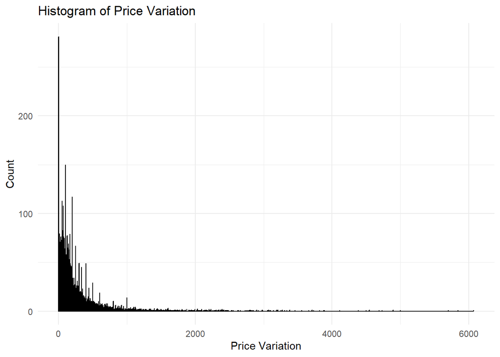

```r
ggplot(variations, aes(x = absolute_variation)) +
  geom_histogram(binwidth = 1, color = "black", fill = "skyblue") +
  labs(x = "Price Variation", y = "Count", title = "Histogram of Price Variation") + theme_minimal()
```

Orientation: dwellings with no location.

```r
exploratory
```

```
## # A tibble: 32,840 × 25
## # Groups:   id [13,829]
##    id            period  price built_area price_sq_m n_room n_bath terrace  lift
##    <fct>         <year>  <dbl>      <int>      <dbl>  <int>  <int>   <int> <int>
##  1 A10001362419… 2018 … 230000         28      8214.      1      1       0     1
##  2 A10001362419… 2018 … 210000         28      7500       1      1       0     1
##  3 A10001362419… 2018 … 215000         28      7679.      1      1       0     1
##  4 A10001425521… 2018 … 396000        130      3046.      4      2       1     1
##  5 A10001425521… 2018 … 387000        130      2977.      4      2       1     1
##  6 A10001980858… 2018 … 280000        100      2800       3      2       0     1
##  7 A10001980858… 2018 … 271000        100      2710       3      2       0     1
##  8 A10001980858… 2018 … 270000        100      2700       3      2       0     1
##  9 A10002838477… 2018 … 149000         62      2403.      2      1       0     0
## 10 A10002838477… 2018 … 148000         62      2387.      2      1       0     0
## # ℹ 32,830 more rows
## # ℹ 16 more variables: air_cond <int>, parking <int>, boxroom <int>,
## #   wardrobe <int>, pool <int>, doorman <int>, garden <int>, external <dbl>,
## #   year_built <int>, floors <int>, n_dwelling <int>, km_to_center <dbl>,
## #   metro_proximity <dbl>, long <dbl>, lat <dbl>, orientation <fct>
```

```r
exploratory_orientation <- exploratory %>%
  group_by(id) %>%
  filter(orientation == "None") %>%
  slice(1) # select the first row that satisfies the condition

mean(exploratory_orientation$year_built)
```

```
## [1] 1966.491
```

## REFERENCES

CSSLab UC3M (2023). Data Visualization: Principles and Practice. Retrieved April 4, 2023, from https://csslab.uc3m.es/dataviz/

Expansion.com. (2019). Historical Euribor 2018. Datosmacro. Retrieved April 21, 2023, from https://datosmacro.expansion.com/hipotecas/euribor?anio=2018

Cimentada, J. (2023). Data Harvesting with R. Retrieved March 29, 2023, from https://cimentadaj.github.io/dataharvesting/

Datahippo. (2018, October 1). Datahippo.org. Madrid (Provincia): Datos básicos Airbnb. Retrieved April 17, 2023, from https://datahippo.org/es/region/599230b08a46554edf88466b/

Medina M. (2023). R Programming. University Carlos III of Madrid.

Open Data Portal of Madrid City Council. (2023). Educational centers in Madrid. Retrieved May 3, 2023, from https://datos.madrid.es/sites/v/index.jsp?vgnextoid=f14878a6d4556810VgnVCM1000001d4a900aRCRD&vgnextchannel=374512b9ace9f310VgnVCM100000171f5a0aRCRD

Open Data Portal of Madrid City Council. (2023). Main parks and municipal gardens in Madrid. Retrieved May 3, 2023, from https://datos.madrid.es/portal/site/egob/menuitem.c05c1f754a33a9fbe4b2e4b284f1a5a0/?vgnextoid=dc758935dde13410VgnVCM2000000c205a0aRCRD&vgnextchannel=374512b9ace9f310VgnVCM100000171f5a0aRCRD&vgnextfmt=default

Open Data Portal of Madrid City Council. (2023). Medical care centers in Madrid. Retrieved May 3, 2023, from https://datos.madrid.es/sites/v/index.jsp?vgnextoid=da7437ac37efb410VgnVCM2000000c205a0aRCRD&vgnextchannel=374512b9ace9f310VgnVCM100000171f5a0aRCRD

Rey-Blanco D., Arbués P., Lopez F., Páez A. (2021). idealista18: Idealista 2018 Data Package. R package version 0.1.1. URL: https://paezha.github.io/idealista18/